# Results_Comparison

juin 25, 2024

## Data comparison

In this script we analyse the intersection of discovered mutations with in both of the analyses

```r
my_data <- fread("all_genes.tsv")
Remy_data <- fread("Remy_Mutations.tsv")
genes_of_interest <- fread(input = "Panel_TSV8.csv")#this is the gene symbol list with all the interesting genes
genes_of_interest <- unique(genes_of_interest$`V8 panel`)
```

And now we’ll select only common samples, present in both analyses

```r
common_samples <- unique(intersect(my_data$Sample, Remy_data$Sample_Name))
my_data_common <- my_data[Sample %in% common_samples]
Remy_data_common <- Remy_data[Sample_Name %in% common_samples]
```

Well, now we see 27 samples present in the both analyses. Here are they PDAC003T, PDAC004T, PDAC005T, PDAC007T, PDAC008T, PDAC011T, PDAC013T, PDAC014T, PDAC015T, PDAC017T, PDAC018T, PDAC019T, PDAC020T, PDAC021T, PDAC024T, PDAC025T, PDAC027T, PDAC028T, PDAC029T, PDAC030T, PDAC031T, PDAC023T, PDAC009T, PDAC012T, PDAC026T, PDAC016T, PDAC022T.  
But of special attention - in the latest analysis we do have 263 variants in Exome analysis vs 2341 variants in Remy’s analysis with chip. Almost 10-times difference!

### Genes abundance

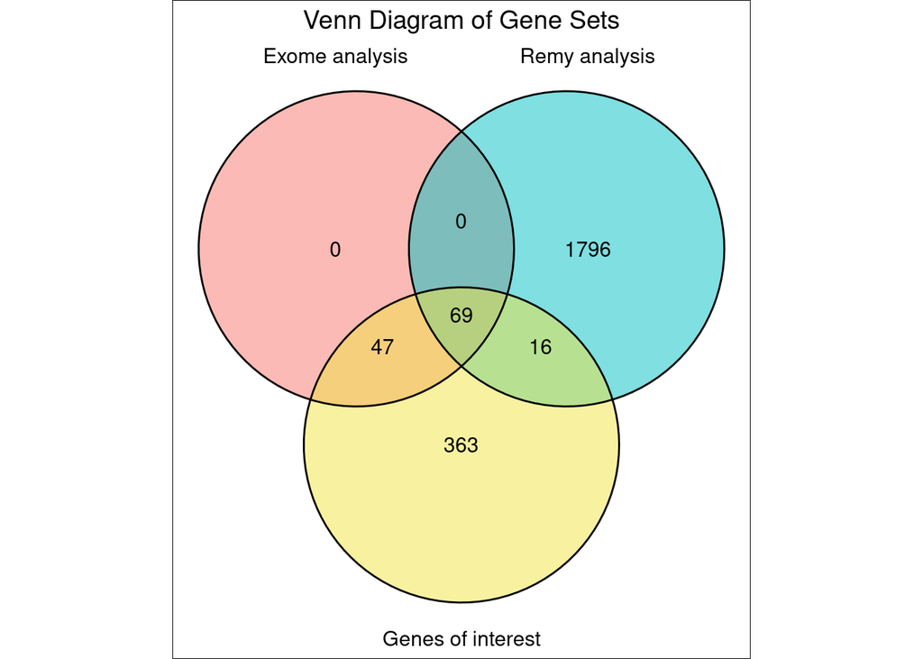

From this Venn diagram we can see the differences in the gene number in 2 data analyses. “Genes of interest” set - is the gene symbol list from file “Panel_TSV8.csv”  
And we can draw 2 major conclusions here:

- The exome analysis and previous analysis are not directly comparable, because they comprise different gene numbers
- To compare the mutations we should remove all the gene symbols not included in the Genes of interest

#### Cleaning-up the genes in the Remy’s analysis

```r
Remy_data_goi <- Remy_data_common[Gene.refGene %in% genes_of_interest]
```

Well, now we see 170 mutations in the Remy’s analysis. It is even fewer than in my analysis - 263!

And now let’s see how it’s look like on the Venn diagram

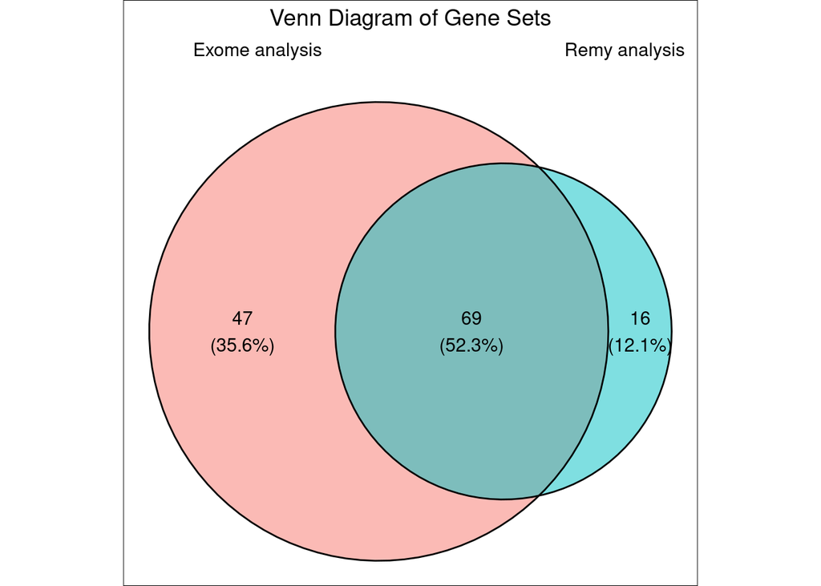

#### Gene sets comparison

Lets look at the genes, present in the Exome analysis only

```
##  [1] "PARP9"   "REV3L"   "FUBP1"   "NFE2L2"  "FLT4"    "MDC1"    "CCND3"
##  [8] "PTK7"    "ROS1"    "SGK1"    "PMS2"    "EZH2"    "IL2RA"   "SIRT1"
## [15] "EXT2"    "ATM"     "H2AFX"   "PARP2"   "NF1"     "LIG1"    "DMD"
## [22] "CDC73"   "WRN"     "MINK1"   "NSD1"    "EXT1"    "FYN"     "ABL1"
## [29] "CTLA4"   "LCK"     "ITGAV"   "RAD18"   "CACNA1S" "NCOR2"   "PDGFRB"
## [36] "YES1"    "PIK3R1"  "MGA"     "NTRK3"   "PSMC3IP" "SF3B1"   "SOX17"
## [43] "INPPL1"  "ITGAL"   "NOTCH4"  "MAPK1"   "ADNP"
```

Common genes

```
##  [1] "ARID1A"   "LRP1B"    "MAP2"     "NCAM1"    "KRAS"     "TP53"
##  [7] "MAP2K4"   "PCNA"     "USH2A"    "FANCL"    "NEB"      "TGFBR2"
## [13] "FAT1"     "CSMD3"    "PALB2"    "ZFHX3"    "FANCA"    "RECQL5"
## [19] "SMAD4"    "ASXL1"    "MXRA5"    "RFC1"     "ATRX"     "CTNNA1"
## [25] "SACS"     "ING1"     "BRCA2"    "CRB1"     "MAP3K1"   "MITF"
## [31] "AKAP9"    "FAM135B"  "AJUBA"    "CD22"     "CD33"     "RAD54L"
## [37] "LRRC7"    "COL6A3"   "PIK3CA"   "ACVR1B"   "SMARCB1"  "CD38"
## [43] "MDN1"     "CDKN2A"   "DYNC1H1"  "NOTCH3"   "FES"      "ADAMTS16"
## [49] "TXNDC8"   "TSC1"     "ERCC3"    "FANCD2"   "RSBN1L"   "STK11"
## [55] "DNER"     "L3MBTL3"  "TEK"      "NTRK2"    "FGFR1"    "NOTCH2"
## [61] "MAP3K4"   "STAT3"    "NTRK1"    "POLD1"    "APC"      "GRM1"
## [67] "ERBB4"    "ZNF620"   "GNAS"
```

Well we see here the 69 - and among them - the most important ones - TP53, KRAS, SMAD4, CDKN2A, FGFR1, BRCA2, at least we are not missing VERY important things!

And genes present only in the Remy’s analysis - and NOT detected in exome analysis

```
##  [1] "MORC4"  "KDM6A"  "U2AF1"  "MLLT4"  "REV1"   "ATRNL1" "SLAMF7" "HSPG2"
##  [9] "MUTYH"  "CD248"  "BUB1B"  "MSLN"   "MEN1"   "PARP1"  "FLT3"   "FGFR2"
```

And here we see the gene names we don’t have in Exome analysis - in the same cohort of patients. Let’s review the list of those genes - their functions and possible implications in cancer. I’ve made a request in Uniprot.org database and found all of them. So, let’s review the results in a table.

This was the request

```bash
#That is the query submitted to UNIPROT
curl --form 'from="Gene_Name"' \
     --form 'to="UniProtKB"' \
     --form 'ids="MORC4,KDM6A,U2AF1,MLLT4,REV1,ATRNL1,SLAMF7,HSPG2,MUTYH,CD248,BUB1B,MSLN,MEN1,PARP1,FLT3,FGFR2"' \
     --form 'taxId="9606"' \
     https://rest.uniprot.org/idmapping/run
```

What we’ve obtained - let’s have a look

```r
Remy_only_genes <- fread("Chip_genes_only.tsv")
Remy_only_genes$`Entry Name` <- NULL # Not needed
names(Remy_only_genes) <- c("Gene_symbol", "UNIPROT_ID", "Alt_names", "Protein_length", "Protein_names", "Diseases")
#Cleaning out the things in the "Diseases" column - to make it readable
Remy_only_genes$Diseases <- gsub("\\{.*?\\}", "", Remy_only_genes$Diseases)
setDF(Remy_only_genes)
```

| Gene_symbol | UNIPROT_ID | Alt_names | Protein_length | Protein_names | Diseases |
| --- | --- | --- | --- | --- | --- |
| MEN1 | O00255 | MEN1 SCG2 | 610 | Menin | DISEASE: Familial multiple endocrine neoplasia type I (MEN1) [MIM:131100]: Autosomal dominant disorder characterized by tumors of the parathyroid glands, gastro-intestinal endocrine tissue, the anteri… |
| KDM6A | O15550 | KDM6A UTX | 1401 | Lysine-specific demethylase 6A (EC 1.14.11.68) (Histone demethylase UTX) (Ubiquitously-transcribed TPR protein on the X chromosome) (Ubiquitously-transcribed X chromosome tetratricopeptide repeat prot… | DISEASE: Kabuki syndrome 2 (KABUK2) [MIM:300867]: A congenital intellectual disability syndrome with additional features, including postnatal dwarfism, a peculiar facies characterized by long palpebra… |
| BUB1B | O60566 | BUB1B BUBR1 MAD3L SSK1 | 1050 | Mitotic checkpoint serine/threonine-protein kinase BUB1 beta (EC 2.7.11.1) (MAD3/BUB1-related protein kinase) (hBUBR1) (Mitotic checkpoint kinase MAD3L) (Protein SSK1) | DISEASE: Note=Defects in BUB1B are associated with tumor formation.; DISEASE: Premature chromatid separation trait (PCS) [MIM:176430]: Consists of separate and splayed chromatids with discernible cent… |
| PARP1 | P09874 | PARP1 ADPRT PPOL | 1014 | Poly [ADP-ribose] polymerase 1 (PARP-1) (EC 2.4.2.30) (ADP-ribosyltransferase diphtheria toxin-like 1) (ARTD1) (DNA ADP-ribosyltransferase PARP1) (EC 2.4.2.-) (NAD(+) ADP-ribosyltransferase 1) (ADPRT … |  |
| FGFR2 | P21802 | FGFR2 BEK KGFR KSAM | 821 | Fibroblast growth factor receptor 2 (FGFR-2) (EC 2.7.10.1) (K-sam) (KGFR) (Keratinocyte growth factor receptor) (CD antigen CD332) | DISEASE: Crouzon syndrome (CS) [MIM:123500]: An autosomal dominant syndrome characterized by craniosynostosis, hypertelorism, exophthalmos and external strabismus, parrot-beaked nose, short upper lip,… |
| FLT3 | P36888 | FLT3 CD135 FLK2 STK1 | 993 | Receptor-type tyrosine-protein kinase FLT3 (EC 2.7.10.1) (FL cytokine receptor) (Fetal liver kinase-2) (FLK-2) (Fms-like tyrosine kinase 3) (FLT-3) (Stem cell tyrosine kinase 1) (STK-1) (CD antigen CD… | DISEASE: Leukemia, acute myelogenous (AML) [MIM:601626]: A subtype of acute leukemia, a cancer of the white blood cells. AML is a malignant disease of bone marrow characterized by maturational arrest … |
| MLLT4 | P55196 | AFDN AF6 MLLT4 | 1824 | Afadin (ALL1-fused gene from chromosome 6 protein) (Protein AF-6) (Afadin adherens junction formation factor) | DISEASE: Note=A chromosomal aberration involving AFDN is associated with acute leukemias. Translocation t(6;11)(q27;q23) with KMT2A/MLL1. The result is a rogue activator protein. |
| HSPG2 | P98160 | HSPG2 | 4391 | Basement membrane-specific heparan sulfate proteoglycan core protein (HSPG) (Perlecan) (PLC) [Cleaved into: Endorepellin; LG3 peptide] | DISEASE: Schwartz-Jampel syndrome (SJS1) [MIM:255800]: Rare autosomal recessive disorder characterized by permanent myotonia (prolonged failure of muscle relaxation) and skeletal dysplasia, resulting … |
| U2AF1 | Q01081 | U2AF1 U2AF35 U2AFBP FP793 | 240 | Splicing factor U2AF 35 kDa subunit (U2 auxiliary factor 35 kDa subunit) (U2 small nuclear RNA auxiliary factor 1) (U2 snRNP auxiliary factor small subunit) | DISEASE: Myelodysplastic syndrome (MDS) [MIM:614286]: A heterogeneous group of closely related clonal hematopoietic disorders. All are characterized by a hypercellular or hypocellular bone marrow with… |
| MSLN | Q13421 | MSLN MPF | 630 | Mesothelin (CAK1 antigen) (Pre-pro-megakaryocyte-potentiating factor) [Cleaved into: Megakaryocyte-potentiating factor (MPF); Mesothelin, cleaved form] | DISEASE: Note=Antibodies against MSLN are detected in patients with mesothelioma and ovarian cancer. . |

[output cut: 6 more lines]

From this table we see 5 genes ASSOCIATED with cancer - MEN1, BUB1B, FLT3, MLLT4, MUTYH - but none of them associated with PDAC.

#### Variants review

Let’s have a closer look at the mutations we potentially missed in the exome analysis and try to find out what has happened

|  | Chr | Start | End | Ref | Alt | Func.refGene | Gene.refGene | GeneDetail.refGene | ExonicFunc.refGene | AAChange.refGene | Interpro_domain | Sample_Name | SNmut_Type | mut_Type | isNonSynonymous | MutatedInRNAseq |
| --- | --- | --- | --- | --- | --- | --- | --- | --- | --- | --- | --- | --- | --- | --- | --- | --- |
| 1 | 6 | 168370574 | 168370574 | C | A | exonic | MLLT4 | . | nonsynonymous SNV | MLLT4:NM_001207008:exon32:c.C5191A:p.R1731S,MLLT4:NM_001291964:exon33:c.C5305A:p.R1769S | . | PDAC016T | C&gt;A | SNV | True | 0 |
| 2 | 1 | 45797228 | 45797228 | C | T | exonic | MUTYH | . | nonsynonymous SNV | MUTYH:NM_001048171:exon13:c.G1145A:p.G382D,MUTYH:NM_001048172:exon13:c.G1106A:p.G369D,MUTYH:NM_001048173:exon13:c.G1103A:p.G368D,MUTYH:NM_001048174:exon13:c.G1103A:p.G368D,MUTYH:NM_001128425:exon13:c.… | MutY, C-terminal;NUDIX hydrolase domain;NUDIX hydrolase domain-like | PDAC024T | C&gt;T | SNV | True | 0 |
| 3 | 6 | 168370574 | 168370574 | C | A | exonic | MLLT4 | . | nonsynonymous SNV | MLLT4:NM_001207008:exon32:c.C5191A:p.R1731S,MLLT4:NM_001291964:exon33:c.C5305A:p.R1769S | . | PDAC024T | C&gt;A | SNV | True | 0 |
| 4 | 15 | 40498503 | 40498503 | T | C | exonic | BUB1B | . | nonsynonymous SNV | BUB1B:NM_001211:exon15:c.T1853C:p.V618A | . | PDAC024T | T&gt;C | SNV | True | 0 |
| 5 | 11 | 64577386 | 64577386 | T | G | exonic | MEN1 | . | nonsynonymous SNV | MEN1:NM_000244:exon2:c.A196C:p.S66R,MEN1:NM_130799:exon2:c.A196C:p.S66R,MEN1:NM_130800:exon2:c.A196C:p.S66R,MEN1:NM_130801:exon2:c.A196C:p.S66R,MEN1:NM_130802:exon2:c.A196C:p.S66R,MEN1:NM_130803:exon2… | . | PDAC027T | T&gt;G | SNV | True | 1 |
| 6 | 13 | 28644663 | 28644663 | C | T | exonic | FLT3 | . | nonsynonymous SNV | FLT3:NM_004119:exon2:c.G130A:p.D44N | . | PDAC030T | C&gt;T | SNV | True | 0 |

Well, I can say nothing about these mutations, based on this data. The only thing is it really concerns only these 4 patients PDAC016T, PDAC024T, PDAC027T, PDAC030T

###Variants abundance

Let’s review the actual differences in both sets of variations. We’ll start with Venn diagrams and then look closer at differences and try to dissect what has happened actually

####Venn diagram To build the diagrams we actually need to make the variants ID.

```r
Remy_data_common$var_ID <- paste("chr", Remy_data_common$Chr, sep = "") #added the prefix chr
Remy_data_common$var_ID <- paste(Remy_data_common$var_ID, Remy_data_common$Start, Remy_data_common$Gene.refGene, sep = "_" )
my_data_common$var_ID <- paste(my_data_common$CHROM, my_data_common$POS, my_data_common$symbol, sep = "_" )
```

Comparison of the set of variants in both analyses, not taking into account the genes of interest

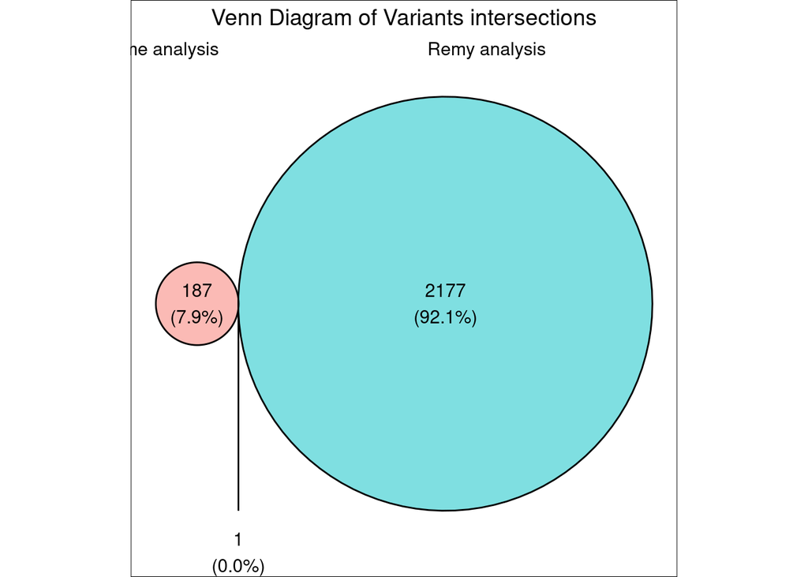

Well, this is weird. Now I see no point in doing any other comparisons in this setting - because our analyses are clearly incomparable

And the only one variation present in both of the analyses.

```r
intersect(my_data_common$var_ID, Remy_data_common$var_ID)
```

```
## [1] "chr9_21974752_CDKN2A"
```

Nico says that it is the problem in references - that’s why the chromosome locations don’t match, and as the consequence - the IDs don’t match

###Protein level mutations only

In this chunk I’ll do the same intersections, but creating IDs in the format like KRAS_GLY12VAL to leverage the references mismatches.

```r
#First, with Remy's data -only with genes of interest, we don't bother with others anymore
Remy_goi_mut_table <- Remy_data_goi[, .(Sample_Name, Gene.refGene, GeneDetail.refGene, AAChange.refGene)]
#Parse out the AAchanges fields
Remy_goi_mut_table <- tidyr::separate_longer_delim(Remy_goi_mut_table, cols = "AAChange.refGene", delim = ",")
Remy_goi_mut_table$AAChange.refGene <- sub(".*:p\\.", "", Remy_goi_mut_table$AAChange.refGene)
Remy_goi_mut_table$AAChange.refGene <- sub(".*(wholegene)", "\\1", Remy_goi_mut_table$AAChange.refGene)
Remy_goi_mut_table <- unique(Remy_goi_mut_table)

#Parsing now the field with nucleotide changes
Remy_goi_mut_table <- tidyr::separate_longer_delim(Remy_goi_mut_table, cols = "GeneDetail.refGene", delim = ",")
Remy_goi_mut_table$GeneDetail.refGene <- sub("NM_.*:", "", Remy_goi_mut_table$GeneDetail.refGene)
Remy_goi_mut_table$GeneDetail.refGene <- paste("splicing:", Remy_goi_mut_table$GeneDetail.refGene, sep = "")
setDT(Remy_goi_mut_table)
Remy_goi_mut_table[AAChange.refGene == ".", AAChange.refGene := GeneDetail.refGene]
Remy_goi_mut_table$GeneDetail.refGene <- NULL
Remy_goi_mut_table <- unique(Remy_goi_mut_table)

#Collapsing mutatons into one line
Remy_goi_mut_table[, Remy_Mutations := paste(AAChange.refGene, collapse = "; "), by = .(Gene.refGene, Sample_Name)]
Remy_goi_mut_table <- Remy_goi_mut_table[, .(Sample_Name, Gene.refGene, Remy_Mutations)]
#Renaming columns
setnames(Remy_goi_mut_table, old = c("Sample_Name", "Gene.refGene"), new = c("Sample", "Gene_symbol"))
Remy_for_merge <- Remy_goi_mut_table[, .(Sample, Gene_symbol, Remy_Mutations)]
```

Let’s have a look what we’ve got.

|  | Sample | Gene_symbol | Remy_Mutations |
| --- | --- | --- | --- |
| 1 | PDAC003T | LRP1B | L2992F |
| 2 | PDAC003T | MAP2 | T860M |
| 3 | PDAC003T | NCAM1 | A589V; A599V; A625V |
| 4 | PDAC003T | NCAM1 | A589V; A599V; A625V |
| 5 | PDAC003T | NCAM1 | A589V; A599V; A625V |
| 6 | PDAC003T | KRAS | G12D |
| 7 | PDAC003T | TP53 | Q4P; Q97P; Q136P |
| 8 | PDAC003T | TP53 | Q4P; Q97P; Q136P |
| 9 | PDAC003T | TP53 | Q4P; Q97P; Q136P |
| 10 | PDAC003T | MAP2K4 | splicing:c.1119+1G&gt;T; splicing:c.1086+1G&gt;T |

[output cut: 296 more lines]

And let’s parse out my table from Exome analysis

```r
Exome_data_goi_mut_table <- my_data_common[, .(symbol, Sample, Consequence, AA_mutations)]
Exome_data_goi_mut_table <- unique(Exome_data_goi_mut_table)
```

```r
# This function was made thanks to chatGPT


# Define the conversion function

convert_mutation <- function(mutation) {

  # Create a look up table for amino acid codes
  amino_acid_lookup <- c(
  Ala = "A", Arg = "R", Asn = "N", Asp = "D", Cys = "C",
  Gln = "Q", Glu = "E", Gly = "G", His = "H", Ile = "I",
  Leu = "L", Lys = "K", Met = "M", Phe = "F", Pro = "P",
  Ser = "S", Thr = "T", Trp = "W", Tyr = "Y", Val = "V",
  Ter = "*")

  # Define patterns for different mutation types
  standard_pattern <- "([A-Za-z]{3})([0-9]+)([A-Za-z]{3})"
  frameshift_pattern <- "([A-Za-z]{3})([0-9]+)([A-Za-z]{3})fsTer([0-9]+)"

  # Match against frameshift pattern first
  frameshift_matches <- regmatches(mutation, regexec(frameshift_pattern, mutation))[[1]]

  if (length(frameshift_matches) > 0) {
    original_aa <- amino_acid_lookup[frameshift_matches[2]]
    position <- frameshift_matches[3]
    new_aa <- amino_acid_lookup[frameshift_matches[4]]
    fs_position <- frameshift_matches[5]
    converted_mutation <- paste0(original_aa, position, new_aa, "fs*", fs_position)
    return(converted_mutation)
  }

  # Match against standard pattern
  standard_matches <- regmatches(mutation, regexec(standard_pattern, mutation))[[1]]

  if (length(standard_matches) > 0) {
    original_aa <- amino_acid_lookup[standard_matches[2]]
    position <- standard_matches[3]
    new_aa <- amino_acid_lookup[standard_matches[4]]
    converted_mutation <- paste0(original_aa, position, new_aa)
    return(converted_mutation)
  }

  return(NA)
}

Exome_data_goi_mut_table$AA_mut_1_letter <- sapply(Exome_data_goi_mut_table$AA_mutations, convert_mutation)
```

```r
Exome_data_goi_mut_table[AA_mutations == ".", AA_mut_1_letter := Consequence]
setnames(Exome_data_goi_mut_table, old = "symbol", new = "Gene_symbol")
Exome_for_merge <- Exome_data_goi_mut_table[, .(Gene_symbol, Sample, AA_mut_1_letter)]
Exome_for_merge <- unique(Exome_for_merge)
Exome_for_merge[, Exome_Mutations := paste(AA_mut_1_letter, collapse = "; "), by = .(Gene_symbol, Sample)]
Exome_for_merge <- unique(Exome_for_merge[, .(Gene_symbol, Sample, Exome_Mutations)])
```

```r
comparison_table <- merge(Exome_for_merge, Remy_for_merge)
comparison_table <- unique(comparison_table)
```

Ok, Nelson is happy now. So, for now, I’ll export this to excel and separate patient mark it by hands

```r
fwrite(comparison_table, "Comparison_table.tsv", sep = "\t")
```

####Comparison in numbers

Here we would like to create a table of coincident mutations per patient, like this: | Sample | Percentage | total number | Exome_only | Chip_only | common_muts

```r
num_comparison <- comparison_table
num_comparison[, Exome_Mutations := lapply(Exome_Mutations, function(x) strsplit(x, ";")[[1]])]
num_comparison[, Remy_Mutations := lapply(Remy_Mutations, function(x) strsplit(x, ";")[[1]])]
num_comparison[, total_number := length(union(unlist(Exome_Mutations), unlist(Remy_Mutations))), by = Sample]
num_comparison[, common_muts := paste(intersect(unlist(Exome_Mutations), unlist(Remy_Mutations)), collapse = "; "), by = Sample]

#Calculating the percentage of the common genes
num_comparison[, percentage := length(intersect(unlist(Exome_Mutations), unlist(Remy_Mutations))), by = Sample]
num_comparison$percentage <- round(num_comparison$percentage / num_comparison$total_number*100, digits = 1)

num_comparison[, Chip_only := paste(setdiff(unlist(Remy_Mutations), unlist(Exome_Mutations)), collapse = "; "), by = Sample]
num_comparison[, Exome_only := paste(setdiff(unlist(Exome_Mutations), unlist(Remy_Mutations)), collapse = "; "), by = Sample]

#I can add some information to that, but I guess, it is good enough to use

fwrite(num_comparison, "numeric_comparison_ChipvsExome.tsv")
```